# iLab3: Comparing Means

Nathaniel Evans

November 12, 2018

# Overview

## Data: csv

## Paper: [Science Direct](https://www.sciencedirect.com/science/article/pii/S0269749199002614?via%3Dihub#TBL2)

## Codebook:

### Variables in this dataset include:

#### Fisherman indicator (fisherman)

#### Age in years (age)

#### Residence Time in years (restime)

#### Height in cm (height)

#### Weight in kg (weight)

#### Fish meals per week (fishmlwk)

#### Parts of fish consumed:0=none, 1=muscle tissue only, 2=mt and sometimes whole fish, 3=whole fish (fishpart)

#### Methyl Mercury in mg/g (methyl_mercury)

#### Total Mercury in mg/g (total_mercury)

## Research Question

### **Do fishermen have different levels of total mercury than non-fishermen?**

# EDA

#### Honestly, I did a significant amount of EDA the last time using this dataset, so I’m going to leave filling out the EDA to the revision portion.

## Download, import data

#### $curl https://raw.githubusercontent.com/apreshill/ohsu-basic-stats/master/data/fishermen_mercury.csv >> fisherman_data.csv

```r
mercury <- read_csv("fisherman_data.csv",
                    col_types = cols(
                      fisherman = col_factor(levels = NULL))
                    )
```

## Looking at the raw values.

```r
mercury %>% glimpse()
```

```
## Observations: 135
## Variables: 9
## $ fisherman      <fct> 1, 1, 1, 1, 1, 1, 1, 1, 1, 1, 1, 1, 1, 1, 1, 1,...
## $ age            <int> 45, 38, 24, 41, 43, 58, 45, 46, 46, 46, 35, 25,...
## $ restime        <int> 6, 13, 2, 2, 11, 2, 6, 0, 14, 5, 2, 2, 0, 12, 1...
## $ height         <int> 175, 173, 168, 183, 175, 176, 184, 170, 175, 17...
## $ weight         <int> 70, 73, 66, 80, 78, 75, 85, 68, 80, 75, 76, 66,...
## $ fishmlwk       <int> 14, 7, 7, 7, 21, 21, 21, 7, 21, 7, 21, 21, 21, ...
## $ fishpart       <int> 2, 1, 2, 1, 1, 1, 1, 2, 1, 1, 2, 2, 2, 2, 2, 2,...
## $ methyl_mercury <dbl> 4.011, 4.026, 3.578, 10.988, 10.520, 6.169, 17....
## $ total_mercury  <dbl> 4.484, 4.789, 3.856, 11.435, 10.849, 6.457, 17....
```

## Computing summary statistics of the variables of interest.

```r
mercury %>% skim()
```

```
## Skim summary statistics
##  n obs: 135
##  n variables: 9
##
## -- Variable type:factor -----------------------------------------------------------------------------------------------------
##   variable missing complete   n n_unique           top_counts ordered
##  fisherman       0      135 135        2 1: 100, 0: 35, NA: 0   FALSE
##
## -- Variable type:integer ----------------------------------------------------------------------------------------------------
##  variable missing complete   n   mean   sd  p0   p25 p50   p75 p100
##       age       0      135 135  33.76 8.03  16  28    32  37.5   58
##  fishmlwk       0      135 135   6.53 5.31   0   2     7   7     21
##  fishpart       0      135 135   1.71 0.7    0   1     2   2      3
##    height       0      135 135 174.41 6.82 154 170   175 180    195
##   restime       0      135 135   4.59 5.16   0   2     2   6     25
##    weight       0      135 135  73.16 6.67  59  68.5  73  77     92
##      hist
##  ▁▃▇▆▂▃▁▁
##  ▃▂▇▁▁▁▁▁
##  ▁▁▂▁▁▇▁▁
##  ▁▂▁▇▇▅▁▁
##  ▇▁▁▁▂▁▁▁
##  ▂▅▇▇▅▃▂▁
##
## -- Variable type:numeric ----------------------------------------------------------------------------------------------------
##        variable missing complete   n mean   sd    p0  p25  p50  p75  p100
##  methyl_mercury       0      135 135 3.64 2.85 0.019 1.86 2.96 4.54 17.21
##   total_mercury       0      135 135 3.78 2.94 0.025 1.9  3.01 4.69 17.79
##      hist
##  ▆▇▃▁▁▁▁▁
##  ▆▇▅▁▁▁▁▁
```

```r
summary(mercury)
```

```
##  fisherman      age           restime           height
##  1:100     Min.   :16.00   Min.   : 0.000   Min.   :154.0
##  0: 35     1st Qu.:28.00   1st Qu.: 2.000   1st Qu.:170.0
##            Median :32.00   Median : 2.000   Median :175.0
##            Mean   :33.76   Mean   : 4.593   Mean   :174.4
##            3rd Qu.:37.50   3rd Qu.: 6.000   3rd Qu.:180.0
##            Max.   :58.00   Max.   :25.000   Max.   :195.0
##      weight         fishmlwk         fishpart     methyl_mercury
##  Min.   :59.00   Min.   : 0.000   Min.   :0.000   Min.   : 0.019
##  1st Qu.:68.50   1st Qu.: 2.000   1st Qu.:1.000   1st Qu.: 1.857
##  Median :73.00   Median : 7.000   Median :2.000   Median : 2.957
##  Mean   :73.16   Mean   : 6.526   Mean   :1.711   Mean   : 3.644
##  3rd Qu.:77.00   3rd Qu.: 7.000   3rd Qu.:2.000   3rd Qu.: 4.539
##  Max.   :92.00   Max.   :21.000   Max.   :3.000   Max.   :17.214
##  total_mercury
##  Min.   : 0.025
##  1st Qu.: 1.904
##  Median : 3.006
##  Mean   : 3.775
##  3rd Qu.: 4.688
##  Max.   :17.788
```

```r
mercury %>% filter(fisherman==1) %>% summary()
```

```
##  fisherman      age           restime          height          weight
##  1:100     Min.   :16.00   Min.   : 0.00   Min.   :154.0   Min.   :59.0
##  0:  0     1st Qu.:28.00   1st Qu.: 1.00   1st Qu.:170.0   1st Qu.:68.0
##            Median :33.00   Median : 3.00   Median :173.5   Median :72.5
##            Mean   :34.92   Mean   : 5.36   Mean   :174.2   Mean   :72.8
##            3rd Qu.:42.00   3rd Qu.:11.00   3rd Qu.:180.0   3rd Qu.:76.0
##            Max.   :58.00   Max.   :25.00   Max.   :195.0   Max.   :92.0
##     fishmlwk        fishpart   methyl_mercury   total_mercury
##  Min.   : 3.00   Min.   :1.0   Min.   : 0.019   Min.   : 0.025
##  1st Qu.: 7.00   1st Qu.:2.0   1st Qu.: 2.091   1st Qu.: 2.244
##  Median : 7.00   Median :2.0   Median : 3.461   Median : 3.732
##  Mean   : 8.45   Mean   :1.9   Mean   : 4.025   Mean   : 4.181
##  3rd Qu.: 7.00   3rd Qu.:2.0   3rd Qu.: 4.966   3rd Qu.: 5.133
##  Max.   :21.00   Max.   :3.0   Max.   :17.214   Max.   :17.788
```

```r
mercury %>% filter(fisherman==0) %>% summary()
```

```
##  fisherman      age           restime        height          weight
##  1: 0      Min.   :26.00   Min.   :1.0   Min.   :170.0   Min.   :61.00
##  0:35      1st Qu.:28.00   1st Qu.:2.0   1st Qu.:174.0   1st Qu.:70.00
##            Median :30.00   Median :2.0   Median :175.0   Median :74.00
##            Mean   :30.43   Mean   :2.4   Mean   :175.1   Mean   :74.17
##            3rd Qu.:32.00   3rd Qu.:3.0   3rd Qu.:178.5   3rd Qu.:78.00
##            Max.   :35.00   Max.   :3.0   Max.   :180.0   Max.   :84.00
##     fishmlwk        fishpart     methyl_mercury  total_mercury
##  Min.   :0.000   Min.   :0.000   Min.   :0.730   Min.   :0.745
##  1st Qu.:0.000   1st Qu.:0.000   1st Qu.:1.059   1st Qu.:1.125
##  Median :1.000   Median :1.000   Median :2.369   Median :2.478
##  Mean   :1.029   Mean   :1.171   Mean   :2.556   Mean   :2.617
##  3rd Qu.:2.000   3rd Qu.:2.000   3rd Qu.:3.589   3rd Qu.:3.653
##  Max.   :2.000   Max.   :2.000   Max.   :5.106   Max.   :5.214
```

## Creating informative visualizations.

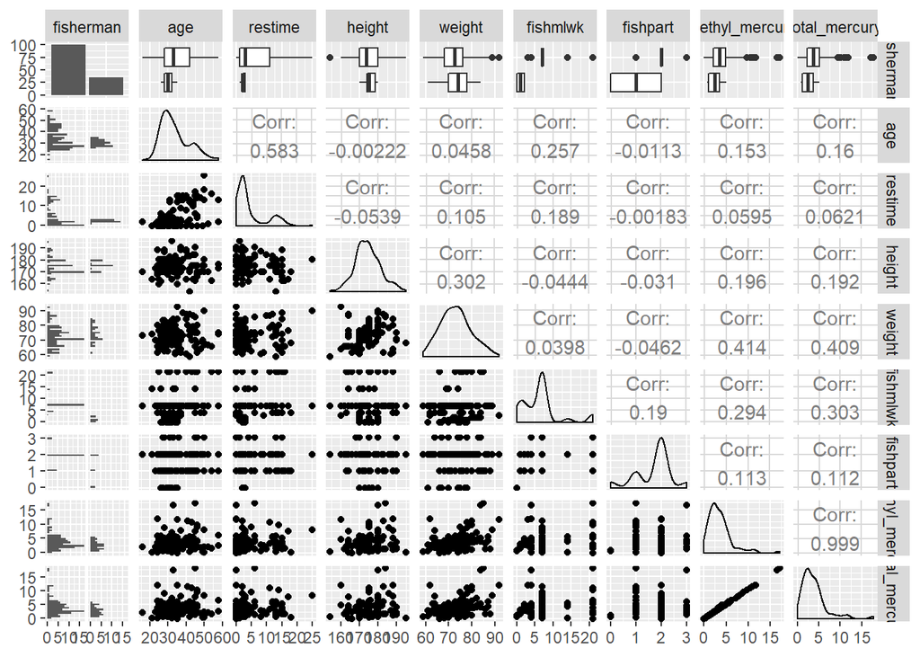

```r
ggpairs(mercury)
```

# Check Conditions

## t-test for two independant samples

### Z-Score Formula

$$Z = \frac{x-\mu}{\sigma}$$

### T-statisitc Formula

$$T = \frac{ (\bar{x_1} - \bar{x_2}) - (\mu_1 - \mu_2) }{s_p \times \sqrt{\frac{1}{n_1} + \frac{1}{n_2}}}$$

$$S_p = \sqrt{\frac{(n_1-1) \times s_1^2 + (n_2-1) \times s_2^2} {n_1 + n_2 -2}}$$

### “A t-value of 0 indicates that the sample results exactly equal the null hypothesis. As the difference between the sample data and the null hypothesis increases, the absolute value of the t-value increases.”

### BUT under null hypthesis mu1-mu2 = 0

## Test Statistic

```r
# n1 is non-fisherman, n2 is fisherman
n1 <- mercury %>% filter(fisherman==0) %>% nrow()
n2 <- mercury %>% filter(fisherman==1) %>% nrow()
s1 <- (mercury %>% filter(fisherman==0))$total_mercury %>% sd()
s2 <- (mercury %>% filter(fisherman==1))$total_mercury %>% sd()

Sp = sqrt( ((n1-1)*s1^2 + (n2-1)*s2^2)/(n1+n2-2))

xbar1 <- (mercury %>% filter(fisherman==0))$total_mercury %>% mean()
xbar2 <- (mercury %>% filter(fisherman==1))$total_mercury %>% mean()

T = (xbar1 - xbar2) / (Sp * sqrt( (1/n1) + (1/n2) ))

Sp
```

```
## [1] 2.867578
```

```r
T
```

```
## [1] -2.777389
```

### Why is my Test Statistic negative? did I misinterpret xbar and mu?

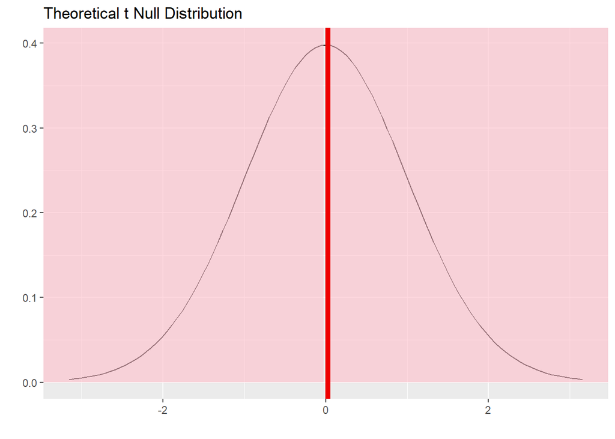

```r
upper_tcrit <- 0.025 # TWO TAIL; 0.05 / 2
test_stat<- mercury %>%
  specify(total_mercury ~ fisherman) %>%
  hypothesize(null = "independence") %>%
  calculate(stat = "t", order = c(1,0))
#test_stat

test_stat %>%  visualize(method = "theoretical",
            obs_stat = upper_tcrit,
            direction = "both") # gives us shading
```

## Observed Effect

```r
ttest <- mercury %>%
  t_test(total_mercury ~ fisherman, order = c(1, 0), var.equal = TRUE)
ttest
```

```
## # A tibble: 1 x 6
##   statistic  t_df p_value alternative lower_ci upper_ci
##       <dbl> <dbl>   <dbl> <chr>          <dbl>    <dbl>
## 1      2.78   133 0.00627 two.sided      0.450     2.68
```

```r
t_test_CI <- c(ttest$lower_ci, ttest$upper_ci)
t_test_CI
```

```
## [1] 0.4502225 2.6781233
```

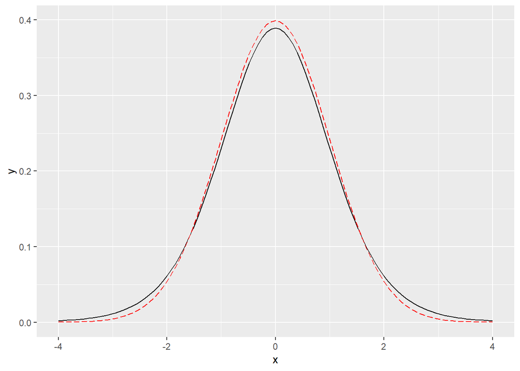

```r
df <- 10
ggplot(data.frame(x = c(-4, 4)), aes(x)) +
  stat_function(fun = dt, args = list(df = df)) + # t dist
  stat_function(fun = dnorm, lty = 5, color = "red") # normal dist in red
```

## The theoretical p-value

But, how can we calculate the p-value from this? Well the easy way is with your infer output :) But! Remember that your observed t-statistic is a quantile value for a statistic that we assume follows a t-distribution. How do we calculate the probability of getting a t-statistic as or more extreme than the one we got? We use pt()!

Use pt() to calculate the 2-sided p-value in R. Does it match the output from infer?

```r
mu_f <- (mercury %>% filter(fisherman==1))$total_mercury %>% mean()
mu_f
```

```
## [1] 4.18083
```

```r
t2 <- (mean(mercury$total_mercury)-mu_f)/(sd(mercury$total_mercury)/sqrt(length(mercury$total_mercury))) #this is compared to the entire population... but I think it's supposed to be just the non-fisherman
t2
```

```
## [1] -1.603447
```

```r
dof <- mercury %>% filter(fisherman==0) %>% nrow()
dof
```

```
## [1] 35
```

```r
# from above
t <- 2.777389
# what about ncp?

pt(q=t, df=dof) # this ends up being supper high
```

```
## [1] 0.9956269
```

#### Well this is clearly incorrect but I’m not sure how to think about this conceptually to remedy it.

## The theorectical confidence interval

Unfortunately, we currently can’t get the confidence interval for theoretical methods using infer. But we can use formulas (yay):

$$\bar{x_1} - \bar{x_2} \pm t * SE_{\bar{x1}-\bar{x_2}}$$

$$SE = s_p \times \sqrt{\frac{1}{n_1} + \frac{1}{n_2}}$$

You should already have variables for the mean difference and the t-statistic critical value(s) (here, t???) from the top formula. In the bottom formula, that standard error should look familiar- it is the standard error of the difference between means. This was the denominator in your calculated t-statistic.

Use these values to calculate the 95% confidence interval for the difference in means. Does it match the output from infer? Does it contain zero? Will this interval ever not contain the observed difference in sample means?

```r
Tcrit <- qt(0.975, 133)
cUP <- abs(xbar1-xbar2) + Tcrit*(Sp * sqrt( (1/n1) + (1/n2) ) )
cLOW <- abs(xbar1-xbar2) - Tcrit*(Sp * sqrt( (1/n1) + (1/n2) ) )

theo_CI <- c(cLOW, cUP)

cUP
```

```
## [1] 2.678123
```

```r
cLOW
```

```
## [1] 0.4502225
```

### YUP! same CI

## Compare t-test to permutation

Using ModernDive 10.7 as an example, as well as our previous resampling lab, conduct a permutation test to evaluate whether there is a mean difference in total mercury between fishermen and non-fishermen. What do you conclude, and how do these results compare to those based on the classical hypothesis test? What, if any, assumptions of each method are comfortable or uncomfortable with?

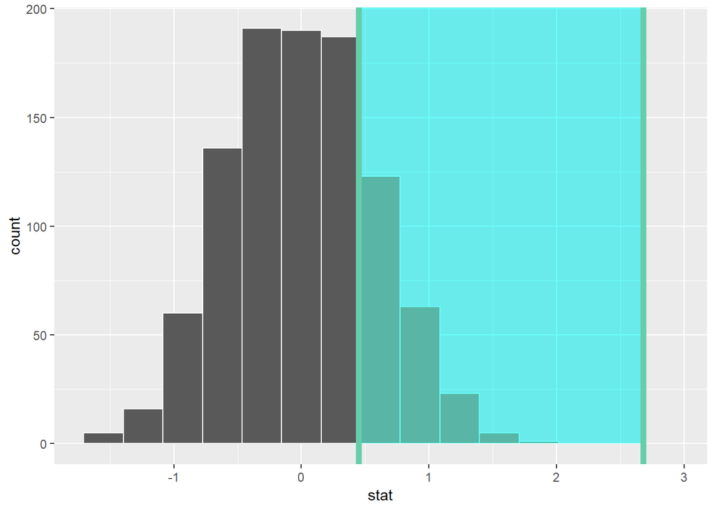

```r
null_distn <- mercury %>%
  specify(total_mercury ~ fisherman) %>%
  hypothesize(null = "independence") %>%
  generate(reps = 1000, type = "permute") %>%
  calculate(stat = "diff in means",
            order = c("0", "1"))

null_distn %>%
  visualize(endpoints = t_test_CI,
            direction = "between") # t_test_CI from above, it would be nice to plot the null distribution too
```

## Compare t-test to linear regression

Use a simple linear regression to analyze total_mercury ~ fisherman. Look carefully at the output, and compare to the output of the classical t-test. What do you notice is the same?

```r
my_lm <- lm(data= mercury, total_mercury ~ fisherman)
summary(my_lm)
```

```
##
## Call:
## lm(formula = total_mercury ~ fisherman, data = mercury)
##
## Residuals:
##     Min      1Q  Median      3Q     Max
## -4.1558 -1.7747 -0.3708  1.0163 13.6072
##
## Coefficients:
##             Estimate Std. Error t value Pr(>|t|)
## (Intercept)   4.1808     0.2868  14.580  < 2e-16 ***
## fisherman0   -1.5642     0.5632  -2.777  0.00627 **
## ---
## Signif. codes:  0 '***' 0.001 '**' 0.01 '*' 0.05 '.' 0.1 ' ' 1
##
## Residual standard error: 2.868 on 133 degrees of freedom
## Multiple R-squared:  0.05482,    Adjusted R-squared:  0.04771
## F-statistic: 7.714 on 1 and 133 DF,  p-value: 0.006272
```

# References

### [1] N.B. Al-Majed and M.R. Preston (2000). “Factors Influencing the Total Mercury and Methyl Mercury in the Hair of Fishermen in Kuwait,” Environmental Pollution, Vol. 109, pp. 239-250.